# Random Variables

Edward A. Roualdes

# Recap

## recap: best guesses

Sample statistics are best guesses about characterstics of the population; we estiamte unknown population parameters with sample statistics, respectively.

| Population Parameter | Sample Statistic |
| --- | --- |
| $\mu$ | $\bar{x}$ |
| $\sigma, s$ | $\hat{\sigma}, \hat{s}$ |
| $\sigma^2, v$ | $\hat{\sigma}^2, \hat{v}$ |
| $p$ | $\hat{p}$ |
| … | … |

# Motivating Distributions

## Distributions, proportions from histogram

We can use a sample (visualized as a histogram) to estimate the proportion of people

- between 180 and 190cm tall, or
- taller than 220cm,
- shorter than 201cm.

## Distributions, proprotions from histogram

Proportion of sample between 180 and 190cm tall?

$\frac{\text{# people between 180 and 190}}{n} =$ 0.3411

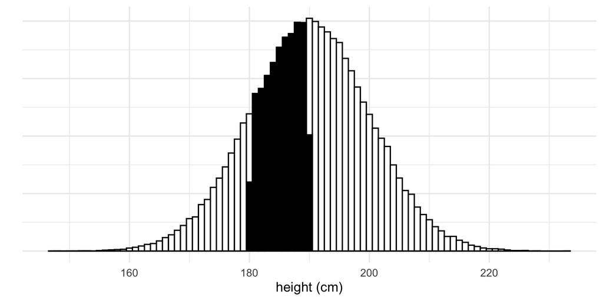

## Distributions, connecting to histograms

We are still estimating things about the popluation. Now we are estimating proportions between two numbers, instead of where the distribution is centered ($\mu$) or how wide the distribution is ($\sigma$).

# Distributions

## Distributions, in simple language

Distributions are the population analogue to histograms, just as $\mu$ is the population analogue to $\bar{X}$. Distributions are mathematical descriptions of populations, defined by a function that has a measure of center $\mu$ and a measure of spread $\sigma$.

## Distributions, an example

We often model adult male heights with a **continuous distribution**. Simplified, this means we draw a curve over a histogram with decreasing binwidths of an infinite set heights.

## Distributions, an example

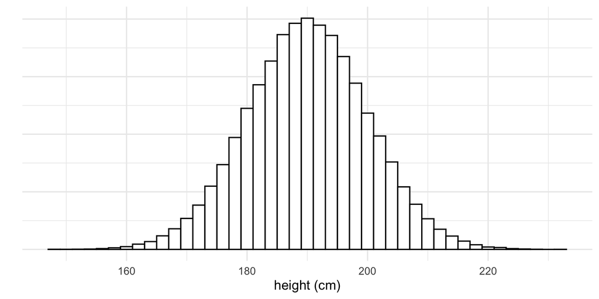

## Distributions, an example

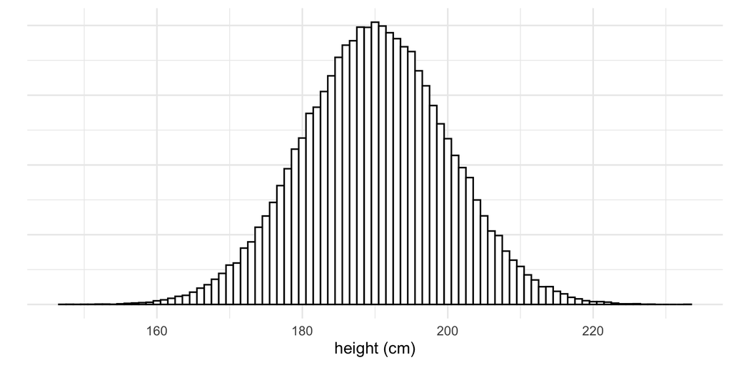

## Distributions, an example

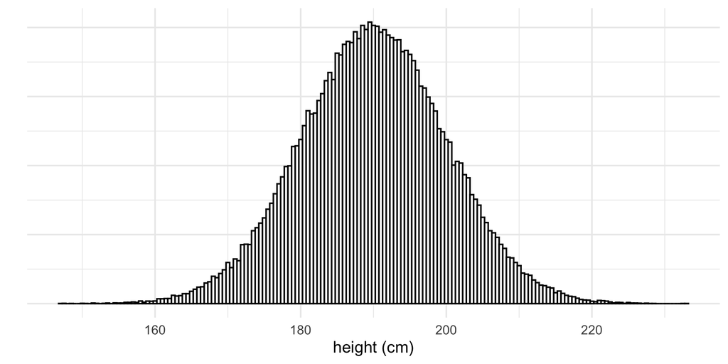

## Distributions, an example

Without a sample, we hypothesize the (population) distribution of heights to have a nice mathematical form.

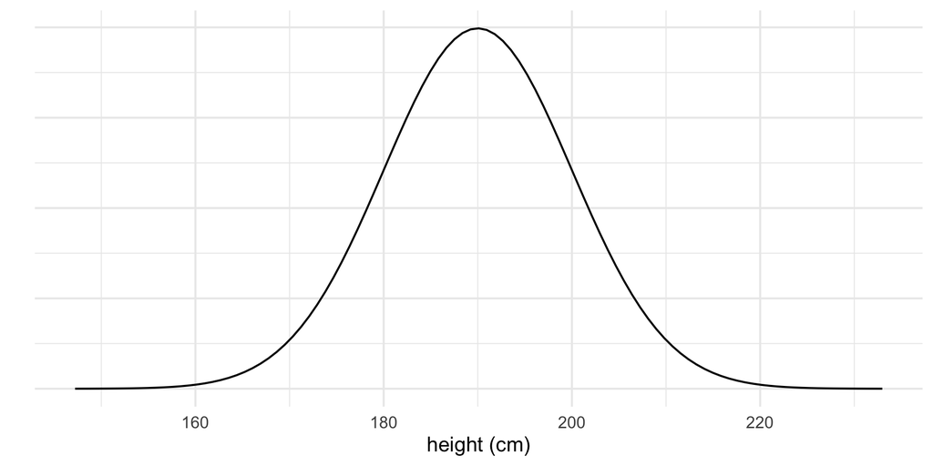

## Continuous Distribution

This smooth curve represents a **probability density function** (also called a **density** or **distribution**). The toal area under the density function is equal to 1.

## Distributions, probability

What is the probability that a randomly selected adult is between 180 and 190cm tall?

$P(180 < X < 190) =$ 0.3413

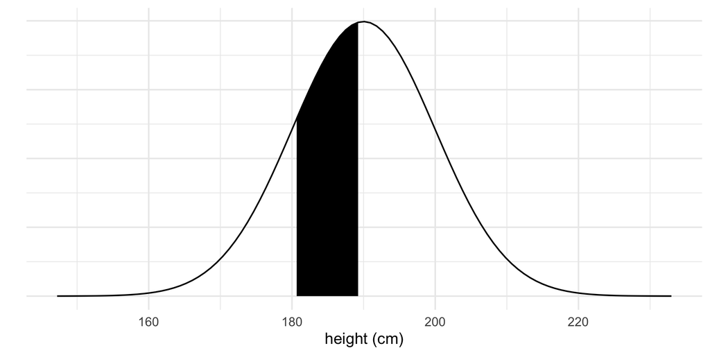

## Distributions, sample estimates population

The proportion of people within the sample in between 180cm and 190cm 0.3411 is a close estimate of the population probability that a randomly chosen person is between those same heights 0.3413.

## Distributions, proprotions from histogram

Proportion of sample less than 201?

$\frac{\# \text{people} < 201}{n} =$ 0.8641

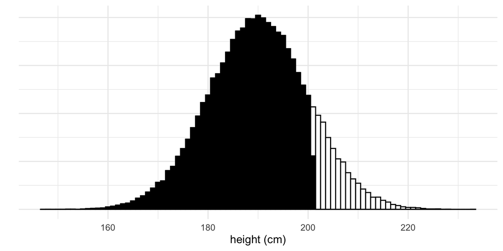

## Distributions, probability

What is the probability that a randomly selected adult is shorter than 201?

$P(X < 201) =$ 0.864

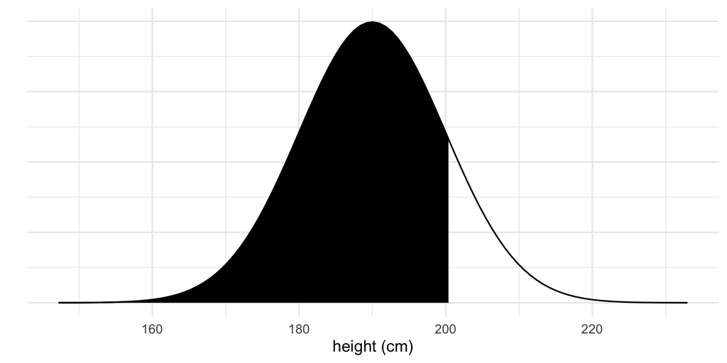

## Distributions, sample estimates population

Again, the proportion of people within the sample that are shorter than 201cm 0.8641 is a close estimate of the population probability that a randomly chosen person is shorter than $201$cm 0.864.

## Distributions, population known?

Though, there is something odd going on. We’ve assumed we know the population distribution; it’s shape, it’s mean, and it’s standard deviation.

## Distributions, in practice

In practice, we don’t and won’t know the population distribution. Nevertheless, we can learn things about it via a sample. Soon we’ll find out that this lack of knowledge about the population, really just doesn’t matter.

# Random Variables

## Random Variables, an example

Continuing our height example: in the case of randomly selected individuals and their height, the random variable $X$ is the height of an unknown (to be randomly selected) individual.

## Random Variables, an example

In this example, the random variable is an adult’s height. Since we don’t yet know how tall a to be randomly selected adult is, we denote the to be determined value by $X$. Once we observe the variable’s outcome, we write the value of the adult as $x$.

## Random Variables, definition

A random process or variable with a numerical outcome, see OS4 Section 3.4.1.

## Random Variables, note

Each random variable has a distribution function that describes the form of the random variable. Tying the pieces together, we say that each random variable (via its distribution function) has a measure of center $\mu$ and a measure of spread $\sigma$.

## Uniform Distribution

The discrete uniform distribution is the simplest of discrete distributions. We write $X \sim U(a, b)$, meaning the random variable $X$ is distributed uniformly on the interval $[a, b]$.

## Uniform Distribution, example

The canonical example is die rolling. If we let the random process of die rolling be denoted by $X$, then $X \sim U(1, 6)$.

## Bernoulli Distribution, motivation I

Suppose you work for the IRS and you are interested in the probability that a randomly selected tax payer is attempting to commit fraud on their tax return. So you and your boss decide to test this. From a sample of 900 tax payers, you perform an in depth search through each of the 900 tax forms.

## Bernoulli Distribution, motivation II

Suppose you want to know the frequency of a dominant gene, say A, in a population<sup>1</sup>. You draw 50 members of the population at random and find that 12 of them display the dominant phenotype.

[^1]: We assume that the population is sufficiently large that removing 50 individuals is without effect and that the population is in Hardy-Weinberg equilibrium.

## Bernoulli Distribution, motivation III

You are interested in calculating the average G/C fraction of Human genomic DNA across the whole genome. You sample $50$ individuals, sequence their genome …

## Bernoulli Distribution, introduction

Notice what is common to all of these scenarios

- random variable has just two outcomes: “success” or “failure”
  - commit fraud or not, dominant or not, G/C base or not
- independent trials
  - your not paying taxes does not (necessarily) determine your neighbor’s willingness to pay taxes, …, G/C base here does not dictate next base
- probability of “success,” $p$, stays the same
  - Bill through Ted have 0.62% chance of commiting fraud, …, dominant gene A shows with frequency of 0.1

## Bernoulli Distribution, more formally

The Bernoulli distribution describes the probability of seeing a successes, calculated from $n$ independent trials with probability of a success $p$.

## Bernoulli Distribution, conditions met?

Let’s discuss: suppose you work for the IRS and you are interested in the probability that a randomly selected tax payer is attempting to commit fraud on their tax return. So you and your boss decide to test this. From a sample of 900 tax payers, you perform an in depth search through each of the 900 tax forms.

## Binomial Distribution

If we can estimate $p$ from a sample of Bernoulli random variables, we can then answer questions of the sort

- What is the probability that 3 of the next 9 tax forms are found to be fradulent?
- What is the probability that 20 of 50 randomly sampled individuals will display the dominant phenotype?
- …

## Binomial Distribution

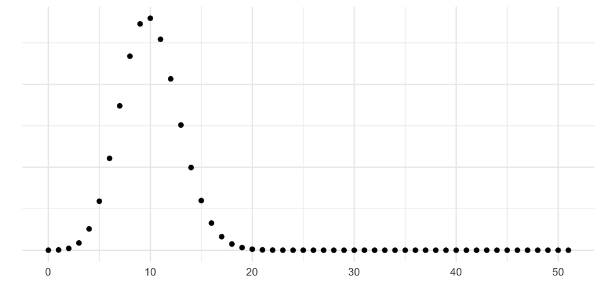

## Normal Distribution

The **normal distribution** is ubiquitous in statistics.

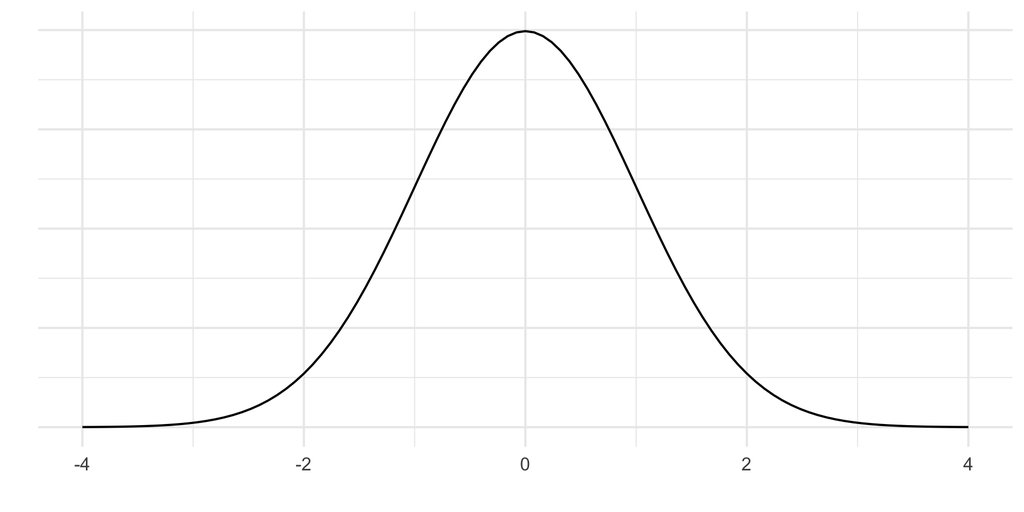

## Normal Distribution

The **normal distribution** is a probability density function that is symmetric, unimodal, and bell shaped.

Notes

- area under the curve is equal to 1,
- perfectly symmetric about $\mu$,
- parameters: centered at $\mu$ with standard deviation $\sigma$,
- often $\mu = 0$, shifts the distribution,
- often $\sigma = 1$, scales the distribution,
- we write in short hand $N(\mu, \sigma)$,
- use $Z$ to denote $N(0,1)$
- [Gau$\beta$ian distribution](https://en.wikipedia.org/wiki/Carl_Friedrich_Gauss)

## Interlude, z-score

The z-score of an observation is the number of standard deviations the observation lies above or below the mean. We compute the z-score for an observation $x$ that follows a distribution with mean $\mu$ and standard deviation $\sigma$ using
$$z = \frac{x - \mu}{\sigma}$$

## z-score notes

- The Z-score is a unitless number. Why?
- By definition, if an observation is 1 standard deviation above its mean, the z-score is 1. If an observation is 1.5 standard deviations below the mean, its z-score is -1.5.

## Z-score, example

- Suppose SAT scores are distributed $X \sim N(1500, 300)$ and ACT scores are distributed $N(21, 5)$. If Ann scored 1800 on the SAT and Tom scored 24 on the ACT, who performed better?
- $z_A = \frac{1800 - 1500}{300} =$ 1
- $z_T = \frac{24 - 21}{5} =$ 0.6
- These are effectively quantiles/percentiles. Picture?

## 68, 95, 99.7 Rule

Use R to justify the following approximate numbers.

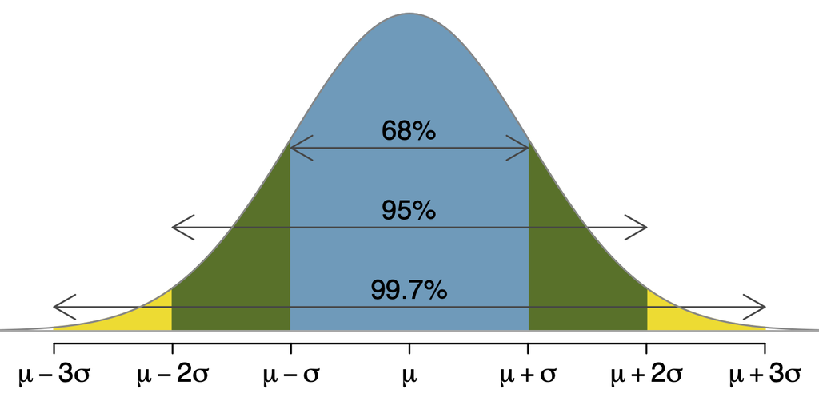

# Parameters

## Random Variables, expected value

All random variables have a theoretical mean, called the **expected value**. The sample mean $\bar{X}$ is the sample analogue of this quantity.

- The expected value of $X$, written $\mu = E(X)$, is the value we’d expect to get out of $X$ is we infinitely repeated the process that generated $X$ and calculated the mean.

## Random Variables, expected value example

Let $Y$ take on the values $0,1$ with equal probability – think coin flip. We can use R to simulate this random variable. We generate a sequence $y_1, y_2, ..., y_{10000}$, each of which will be $0$ or $1$ once observed, and calculate the running mean. That is,

- $Y_1$ evaluates to $y_1$, with mean $y_1 / 1$
- $Y_1, Y_2$ evaluate to $y_1, y_2$, with mean $(y_1 + y_2)/2$
- $Y_1, Y_2, Y_3$ evaluate to $y_1, y_2, y_3$, with mean $(y_1 + y_2 + y_3)/3$
- …
- $Y_1, ..., Y_{10000}$ evaluate to $y_1, ..., y_{10000}$, with mean $\sum_{i=1}^{10000} y_i /10000$.

Since we expect the long-run average of a coin flip to be $1/2$, our running mean should converge to $1/2$.

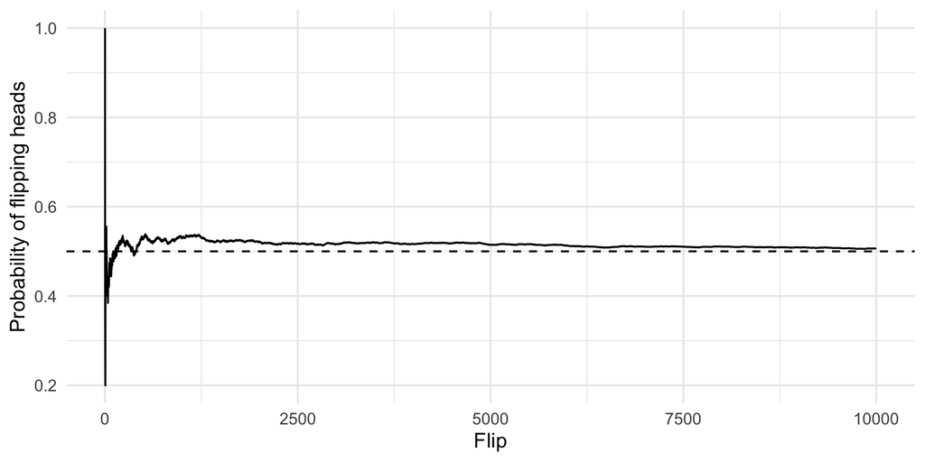

## Random Variables, variance

Random variables also have a common measure of spread, called the **variance**. The squared sample standard deviation, $s^2$, is the sample analogue of this quantity.

- The variance of $X$, written $\sigma^2 = Var(X)$, is the mean of squared deviations about $E(X)$ if we infinitely repeated the process that generated $X$.

## Random Variables, variance example

Consider $Y$ a random variable following a Bernoulli distribution with probability of “success” $p$.

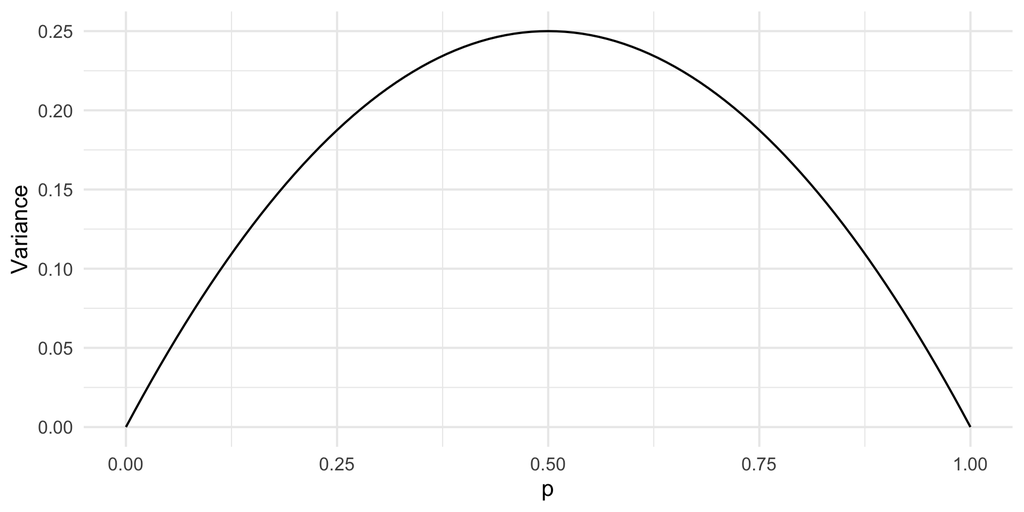

## Random Variables, distributions

Random variables are said to follow specific distribution functions, eg $X$ is distributed as [some name].

We calculate the expected value and variance of random variables from these distribution functions. When we calculate statistics, it is these mathematical quantities that we are estimating.

## Take Away

- We assume distributions describe populations of interest
  - distributions describe the shape of our data
- Distributions have parameters: mean, variance, percentiles, …
- Use data to estimate parameters
  - use data to learn about population